# How Do Political Regimes Shape Leader Tenure and Economic Output?

Different countries run under very different political systems; some are democracies, some are dictatorships, and some fall somewhere in between. This report looks at two questions: **How does leader tenure differ across political regimes?** and **How does economic output differ across regime types?**

## About the Data

The main dataset comes from Cheibub, Gandhi, and Vreeland’s “Democracy and Dictatorship Revisited” (2009), later prepared for the TidyTuesday project by Jon Harmon. It tracks regime classifications for countries worldwide from 1950 to 2020, where each observation is a country in a given year. We also use a country-level health and economic dataset from Kaggle (by Amir Hossein Mirzaei), covering 178 countries from 2000 to 2015. GDP data was accessed through the API Ninjas GDP API, which pulls country-level economic indicators from international sources.

```r
#Chunk used to load needed packages and data sets
#| message: false
#| warning: false

#install.packages("ggridges")
suppressPackageStartupMessages({
  library(tidyverse)
  library(countrycode)
  library(glue)
  library(jsonlite)
  library(palmerpenguins)
  library(gt)
  library(tidyr)
  library(purrr)
  library(ggridges)
  library(stringr)
  library(dplyr)
  library(ggplot2)
  library(scales)
})

meta_data <- suppressMessages(read_csv("meta_data.csv", show_col_types = FALSE))
```

## Leader Tenure Across Regimes

To see how long leaders stay in power under different regimes, we calculated the mean tenure of presidents and monarchs grouped by regime category.

```r
tenure_data <- meta_data |>
  mutate(president_tenure = year - president_accesion_year,
    monarch_tenure = year - monarch_accession_year
  )

# function to get the mean tenure of either presidents or monarchs, and group them by their regime       category
tenure_by_regime <- function(data, leader_type) {
  if (leader_type == "president") {
    data |>
      filter(!is.na(president_name), !is.na(president_tenure)) |>
      group_by(president_name, regime_category) |>
      summarize(tenure = max(president_tenure, na.rm = TRUE), .groups = "drop") |>
      group_by(regime_category) |>
      summarize(mean_tenure = mean(tenure, na.rm = TRUE))
  } else {
    data |>
      filter(!is.na(monarch_name), !is.na(monarch_tenure)) |>
      group_by(monarch_name, regime_category) |>
      summarize(tenure = max(monarch_tenure, na.rm = TRUE), .groups = "drop") |>
      group_by(regime_category) |>
      summarize(mean_tenure = mean(tenure, na.rm = TRUE))
  }
}
```

### How does leader tenure differ across different political regimes?

```r
president_summary <- tenure_by_regime(tenure_data, "president")
monarch_summary <- tenure_by_regime(tenure_data, "monarch")

president_table <- president_summary |>
  arrange(desc(mean_tenure)) |>
  gt() |>
  tab_header(title = "Mean Tenure by Presidential Regimes") |>
  cols_label(regime_category = "Regime Category",
             mean_tenure = "Mean Tenure (years)") |>
  fmt_number(columns = c(mean_tenure),
             decimals = 1) |>
  tab_style(style = cell_text(weight = "bold"),
            locations = cells_column_labels(columns = everything())) |>
  tab_caption("Presidential regimes sorted in descending order by mean tenure length.") |>
  data_color(
    columns = mean_tenure,
    colors = scales::col_numeric(c("#deebf7", "#08519c"), domain = NULL)
  )


president_table
```

Table 1: Presidential regimes sorted in descending order by mean tenure length.

Mean Tenure by Presidential Regimes

| Regime Category | Mean Tenure (years) |
| --- | --- |
| Military dictatorship | 11.7 |
| Civilian dictatorship | 9.6 |
| Unincorporated territory of the United States | 6.0 |
| Unincorporated territory of the United States with Commonwealth status | 6.0 |
| Mixed democratic | 5.9 |
| Parliamentary democracy | 4.8 |
| Presidential democracy | 4.5 |
| Royal dictatorship | 0.0 |

### How does leader tenure differ across presidencies vs. monarchies for various political regimes?

```r
get_tenure <- function(x) {
  tenure_by_regime(tenure_data, x) |>
    mutate(leader_type = x)
}

combined_wide <- map_dfr(c("president", "monarch"), get_tenure)|>
  mutate(leader_type = recode(leader_type,
                              president = "President",
                              monarch = "Monarch")) |>
  pivot_wider(names_from = leader_type,
              values_from = mean_tenure) |>
   drop_na(President, Monarch)
```

```r
comparison_table <- combined_wide |>
  arrange(desc(President)) |>
  gt() |>
  tab_header(title = "Comparison of Mean Leader Tenure Across Regimes") |>
  cols_label(regime_category = "Regime Category",
             President = "President",
             Monarch = "Monarch") |>
  tab_spanner(label = "Mean Tenure (years)",
              columns = c(President, Monarch)) |>
  fmt_number(columns = c(President, Monarch),
             decimals = 1) |>
  tab_style(style = cell_text(weight = "bold"),
            locations = cells_column_labels(columns = everything())) |>
  tab_caption("Comparison of mean presidential and monarchical tenure across regime categories.") |>
  data_color(columns = c(President, Monarch),
  colors = scales::col_numeric(c("#deebf7", "#08519c"), domain = NULL))

comparison_table
```

Table 2: Comparison of mean presidential and monarchical tenure across regime categories.

Comparison of Mean Leader Tenure Across Regimes

| Regime Category | Mean Tenure (years) President | Mean Tenure (years) Monarch |
| --- | --- | --- |
| Military dictatorship | 11.7 | 37.0 |
| Civilian dictatorship | 9.6 | 17.0 |
| Mixed democratic | 5.9 | 4.7 |
| Parliamentary democracy | 4.8 | 26.7 |
| Royal dictatorship | 0.0 | 21.0 |

When looking at the tenures between presidents and monarchs, we can see that monarchs tend to be in power for much longer than presidents. This does not come as a surprise because monarchs are meant to rule for a longer period of time, especially since the power is often inherited by an heir. Even so, military dictatorships seem to be the longest lasting regimes regardless of the ruler being a president versus a monarch.

### Tenure length by different presidential regimes

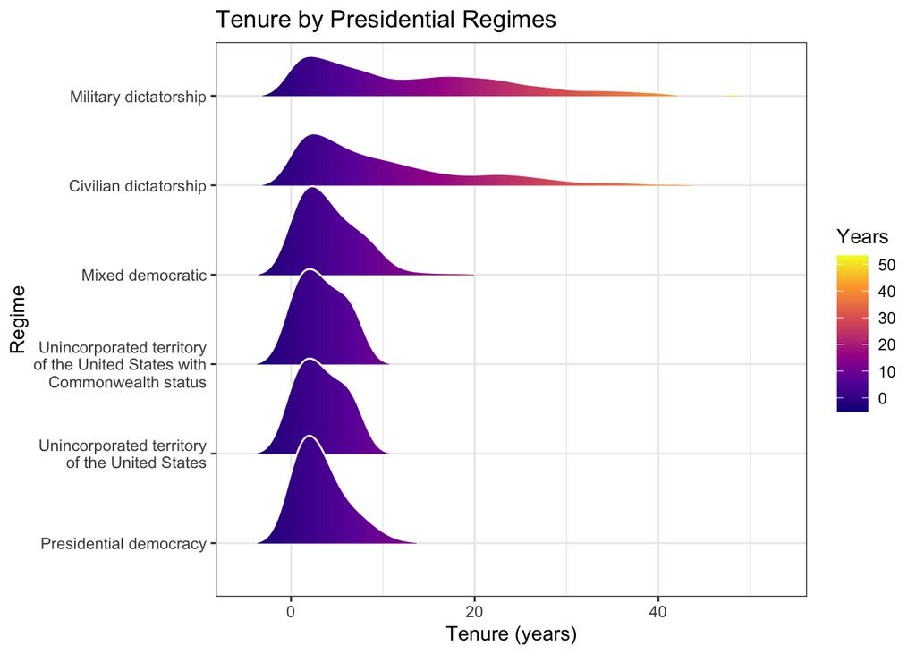

Figure 1: Distribution of presidential tenure across regime types.

```r
tenure_data |>
  filter(!is.na(president_tenure),
         !is.na(regime_category),
         is_presidential == TRUE) |>
  mutate(regime_category = stringr::str_wrap(regime_category, width = 25)) |>
  ggplot(aes(x = president_tenure,
             y = reorder(regime_category, president_tenure, FUN = median),
             fill = after_stat(x))) +
  geom_density_ridges_gradient(scale = 1.2,
                               rel_min_height = 0.01,
                               color = "white",
                               alpha = 0.9) +
  scale_fill_viridis_c(option = "C") +
  labs(title = "Tenure by Presidential Regimes",
       x = "Tenure (years)",
       y = "Regime",
       fill = "Years") +
  theme_bw()
```

In this plot we can see how the distribution of tenure differs among various regime types. The two “outliers” here are military and civilian dictatorships. From the previous tables we saw that these two regimes are the longest lasting, but this plot also shows the spread of the duration of the regime.

### Tenure length by different monarchical regimes

The monarchy side tells a similar story. Looking at individual monarch tenures rather than averages gives us a sense of just how extreme some of these reigns get.

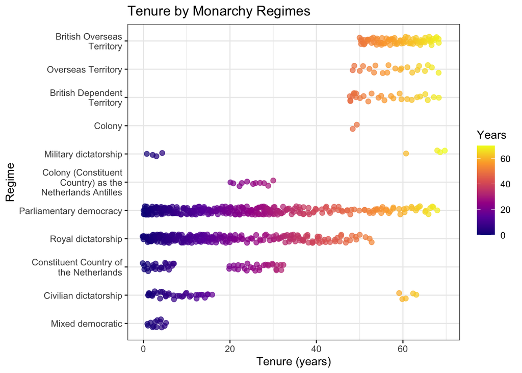

Figure 2: Individual monarch tenure observations by regime type.

```r
tenure_data |>
  filter(!is.na(monarch_tenure), !is.na(regime_category), is_monarchy == TRUE) |>
  mutate(regime_category = stringr::str_wrap(regime_category, width = 25)) |>
  ggplot(aes(x = reorder(regime_category, monarch_tenure),
             y = monarch_tenure,
             color = monarch_tenure)) +
  geom_jitter(width = 0.15, alpha = 0.7, size = 2) +
  coord_flip() +
  scale_color_viridis_c(option = "C") +
  labs(title = "Tenure by Monarchy Regimes",
       x = "Regime",
       y = "Tenure (years)",
       color = "Years") +
  theme_bw()
```

## GDP Across Regime Types

We grouped countries into seven regime categories and compared their mean GDP per capita from 2000 to 2020. Since several territory and colonycategories had fewer than 100 observations each, we combined them into one “Territories & Colonies” group.

```r
combined <- meta_data |>
  filter(!is.na(gdp_per_capita_nominal), regime_category != "NA") |>
  group_by(regime_category) |>
  mutate(regime_group = if_else(n() < 100, "Territories & Colonies",
                                 first(regime_category))) |>
  ungroup()
```

```r
combined |>
  group_by(regime_group) |>
  summarize(
    mean_gdp = mean(gdp_per_capita_nominal, na.rm = TRUE),
    median_gdp = median(gdp_per_capita_nominal, na.rm = TRUE),
    n = n()
  ) |>
  arrange(desc(mean_gdp)) |>
  gt() |>
  tab_header(title = "GDP per Capita by Regime Type") |>
  cols_label(regime_group = "Regime Type",
             mean_gdp = "Mean",
             median_gdp = "Median",
             n = "Observations") |>
  tab_spanner(label = "GDP per Capita (USD)",
              columns = c(mean_gdp, median_gdp)) |>
  fmt_currency(columns = c(mean_gdp, median_gdp),
               currency = "USD", decimals = 2) |>
  fmt_number(columns = n, decimals = 0) |>
  tab_style(style = cell_text(weight = "bold"),
            locations = cells_column_labels()) |>
  data_color(columns = c(mean_gdp, median_gdp),
             palette = c("#deebf7", "#08519c")) |>
  tab_caption("GDP per capita sorted in descending mean GDP by regime type")
```

Table 3: GDP per capita sorted in descending mean GDP by regime type

GDP per Capita by Regime Type

| Regime Type | GDP per Capita (USD) Mean | GDP per Capita (USD) Median | Observations |  |
| --- | --- | --- | --- | --- |
| Territories & Colonies | $33,221.58 | $27,944.74 |  | 85 |
| Parliamentary democracy | $20,681.49 | $13,736.52 | 956 |  |
| Royal dictatorship | $19,891.96 | $16,749.50 | 256 |  |
| Mixed democratic | $13,222.05 | $5,098.01 | 604 |  |
| Presidential democracy | $8,968.70 | $3,952.96 | 760 |  |
| Civilian dictatorship | $4,271.71 | $1,940.12 | 863 |  |
| Military dictatorship | $2,421.95 | $1,098.62 | 400 |  |

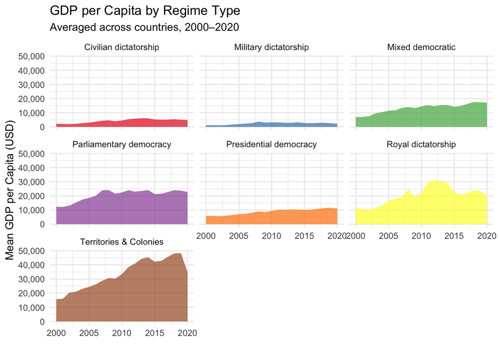

Figure 3: Mean GDP per capita trends by regime type, 2000–2020.

```r
mean_gdp <- combined |>
  group_by(year, regime_group) |>
  summarize(mean_gdp = mean(gdp_per_capita_nominal, na.rm = TRUE),
            .groups = "drop")

ggplot(data = mean_gdp,
       mapping = aes(x = year,
                     y = mean_gdp)) +
  geom_area(mapping = aes(fill = regime_group),
            alpha = 0.7) +
  facet_wrap(~regime_group) +
  scale_y_continuous(labels = comma) +
  scale_fill_brewer(palette = "Set1") +
  labs(x = "", y = "Mean GDP per Capita (USD)",
       title = "GDP per Capita by Regime Type",
       subtitle = "Averaged across countries, 2000–2020",
       fill = "Types of Regime") +
  theme_minimal() +
  theme(legend.position = "none")
```

Figure 3 breaks this down over time. Most regime types saw steady GDP growth from 2000 to 2020, with dips around 2015 and 2020. Territories & Colonies had the biggest growth overall.

## Democracies vs Non-Democracies

Simplifying the comparison down to just democracies versus non-democracies helps us look into the patterns from another perspective.

```r
dem_gdp <- combined |>
  mutate(democracy = if_else(is_democracy == 1, "Democracy", "Non-Democracy")) |>
  group_by(year, democracy) |>
  summarize(mean_gdp = mean(gdp_per_capita_nominal, na.rm = TRUE),
            .groups = "drop")
```

```r
dem_gdp |>
  pivot_wider(names_from = democracy, values_from = mean_gdp) |>
  gt() |>
  tab_header(title = "Mean GDP per Capita: Democracies vs Non-Democracies") |>
  fmt_currency(columns = c(Democracy, `Non-Democracy`), decimals = 0) |>
  tab_style(style = cell_text(weight = "bold"),
            locations = cells_column_labels()) |>
  tab_caption("Mean GDP per capita compared by democracy status, 2000–2020.")
```

Table 4: Mean GDP per capita compared by democracy status, 2000–2020.

Mean GDP per Capita: Democracies vs Non-Democracies

| year | Democracy | Non-Democracy |
| --- | --- | --- |
| 2000 | $9,178 | $3,718 |
| 2001 | $9,026 | $3,725 |
| 2002 | $9,428 | $3,658 |
| 2003 | $11,053 | $4,002 |
| 2004 | $12,234 | $4,834 |
| 2005 | $13,189 | $5,687 |
| 2006 | $13,794 | $6,650 |
| 2007 | $15,913 | $7,333 |
| 2008 | $16,686 | $8,613 |
| 2009 | $15,309 | $7,053 |
| 2010 | $16,270 | $7,955 |
| 2011 | $17,397 | $9,815 |
| 2012 | $16,711 | $10,419 |
| 2013 | $17,421 | $10,421 |
| 2014 | $17,499 | $10,464 |
| 2015 | $15,919 | $8,754 |
| 2016 | $16,286 | $8,379 |
| 2017 | $17,269 | $8,811 |
| 2018 | $18,398 | $9,378 |
| 2019 | $18,331 | $8,991 |
| 2020 | $17,707 | $7,632 |

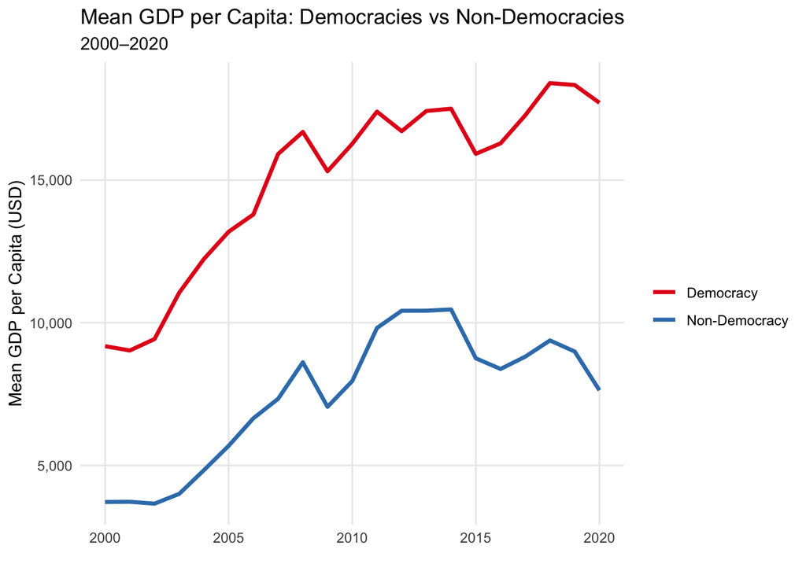

Figure 4: Mean GDP per capita comparison between democracies and non-democracies.

```r
ggplot(dem_gdp, aes(x = year, y = mean_gdp, color = democracy)) +
  geom_line(linewidth = 1.2) +
  scale_color_brewer(palette = "Set1") +
  scale_y_continuous(labels = comma) +
  labs(x = "", y = "Mean GDP per Capita (USD)",
       title = "Mean GDP per Capita: Democracies vs Non-Democracies",
       subtitle = "2000–2020",
       color = "") +
  theme_minimal() +
  theme(panel.grid.minor = element_blank())
```

Table 4 and Figure 4 show that democracies consistently have a higher mean GDP per capita, and the gap between the two groups has widened over time, from roughly a few thousand dollars in 2000 to a noticeably larger spread by 2020. This suggests that democratic institutions may provide a more stable foundation for sustained economic growth.

## Statistical Model

To test whether the differences in leader tenure across regimes are statistically significant, we ran a two-way ANOVA with regime category and year as predictors.

```r
stuff <- meta_data %>%
  mutate(
    leader_tenure = case_when(
      !is.na(monarch_accession_year) ~ year - monarch_accession_year,
      !is.na(president_accesion_year) ~ year - president_accesion_year,
    )
  ) %>%
  select(leader_tenure, regime_category, year) %>%
  na.omit()

stuff$regime_category <- as.factor(stuff$regime_category)
stuff$year <- as.factor(stuff$year)

anova_result <- summary(aov(leader_tenure ~ regime_category + year, data = stuff))

model <- as.data.frame(anova_result[[1]])
model$Term <- rownames(model)
model <- model[, c("Term", "Df", "Sum Sq", "Mean Sq", "F value", "Pr(>F)")]

model %>%
  gt() %>%
  cols_label(
    Term = "Term",
    Df = "Df",
    `Sum Sq` = "Sum of Squares",
    `Mean Sq` = "Mean Square",
    `F value` = "F value",
    `Pr(>F)` = "p-value"
  ) %>%
  fmt_number(
    columns = c(`Sum Sq`, `Mean Sq`, `F value`),
    decimals = 2
  ) %>%
  fmt_scientific(
    columns = `Pr(>F)`,
    decimals = 2
  ) %>%
  cols_align(
    align = "center",
    columns = c(Df, `Sum Sq`, `Mean Sq`, `F value`, `Pr(>F)`)
  ) %>%
  tab_header(
    title = "ANOVA Table of Leader Tenure by Regime Category and Year"
  )
```

ANOVA Table of Leader Tenure by Regime Category and Year

| Term | Df | Sum of Squares | Mean Square | F value | p-value |
| --- | --- | --- | --- | --- | --- |
| regime_category | 14 | 422,568.20 | 30,183.44 | 297.80 | 0.00 |
| year | 20 | 344.48 | 17.22 | 0.17 | 1.00 × 10<sup>0</sup> |
| Residuals | 3858 | 391,022.02 | 101.35 | NA | NA |

The ANOVA results show that leader tenure differs significantly across political regimes (F = 297.80, p < 0.001), meaning the type of regime plays a major role in how long leaders stay in power. The effect of year is not significant (F = 0.17, p ≈ 1.00), meaning there’s no meaningful change in tenure over time once regime type is accounted for. The variation in leader tenure is mainly driven by differences between regimes, not by trends over time.